# Intro to Data Science - HW 5

## Step 4: Explore how the data changes over time

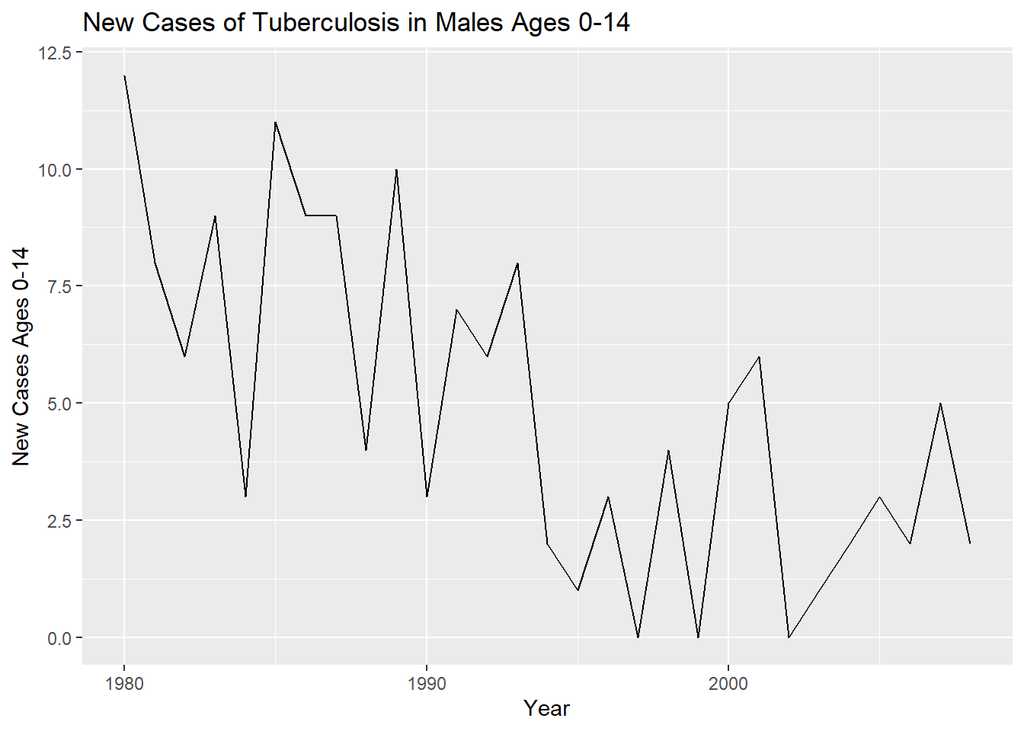

```r
library(ggplot2)
ggplot(data = tbCan, aes(x = tbCan$year, y = tbCan$new_sp_m014)) +
  geom_line() +
  labs(x = "Year", y = "New Cases Ages 0-14", title = "New Cases of Tuberculosis in Males Ages 0-14")
```

11. Next, create similar graphs for each of the other three variables. Change the **color** of the line plots (any color you want).

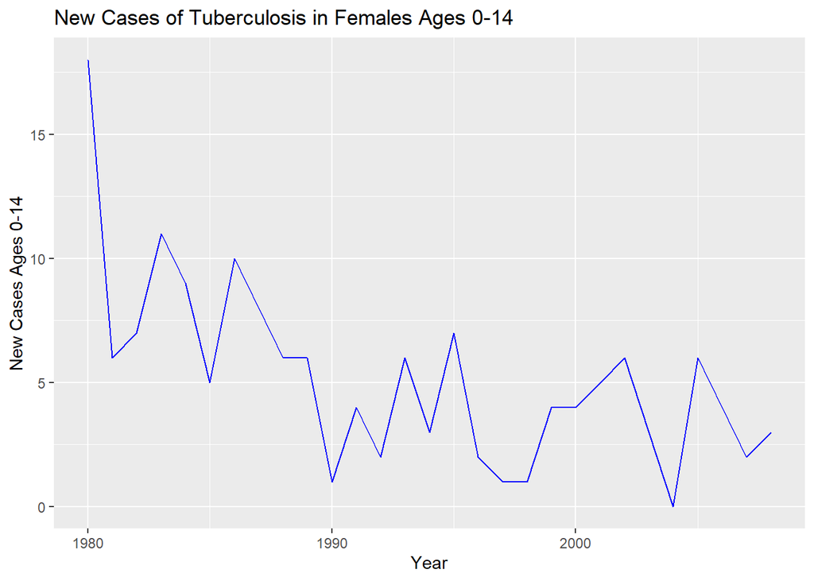

```r
ggplot(data = tbCan, aes(x = tbCan$year, y = tbCan$new_sp_f014)) +
  geom_line(color="blue") +
  labs(x = "Year", y = "New Cases Ages 0-14", title = "New Cases of Tuberculosis in Females Ages 0-14")
```

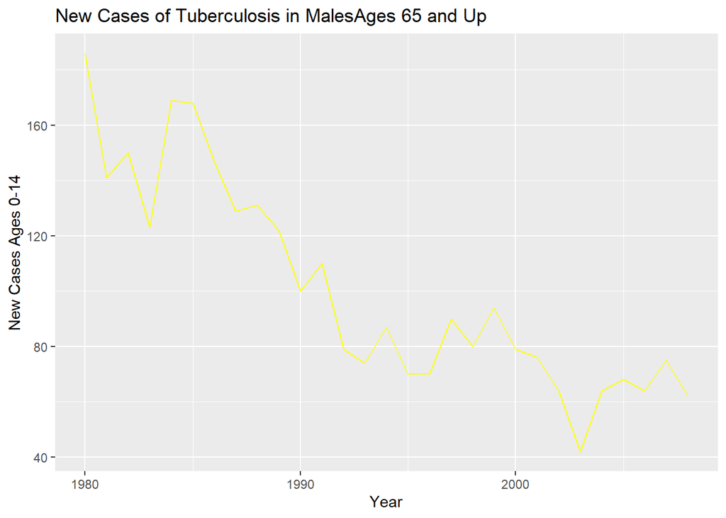

```r
ggplot(data = tbCan, aes(x = tbCan$year, y = tbCan$new_sp_m65)) +
  geom_line(color="yellow") +
  labs(x = "Year", y = "New Cases Ages 0-14", title = "New Cases of Tuberculosis in MalesAges 65 and Up")
```

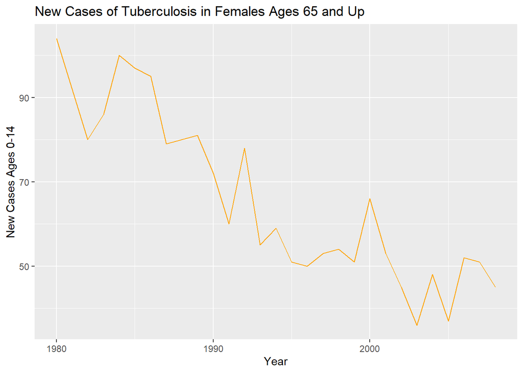

```r
ggplot(data = tbCan, aes(x = tbCan$year, y = tbCan$new_sp_f65)) +
  geom_line(color="orange") +
  labs(x = "Year", y = "New Cases Ages 0-14", title = "New Cases of Tuberculosis in Females Ages 65 and Up")
```

12. Using vector math, create a new variable by combining the numbers from **new_sp_m014** and **new_sp_f014**. Save the resulting vector as a new variable in the **tbCan** df called **new_sp_combined014**. This new variable represents the number of positive pulmonary smear tests for male AND female children between the ages of 0 and 14 years of age. Do the same for SP **tests among citizens 65 years of age and older** and save the resulting vector in the tbCan variable called **new_sp_combined65**.

```r
tbCan$new_sp_combined014 <- tbCan$new_sp_m014 + tbCan$new_sp_f014
tbCan$new_sp_combined65 <- tbCan$new_sp_m65 + tbCan$new_sp_f65
```

13. Finally, create a **scatter plot**, showing **new_sp_combined014** on the x axis, **new_sp_combined65** on the y axis, and having the **color and size** of the point represent **year**.

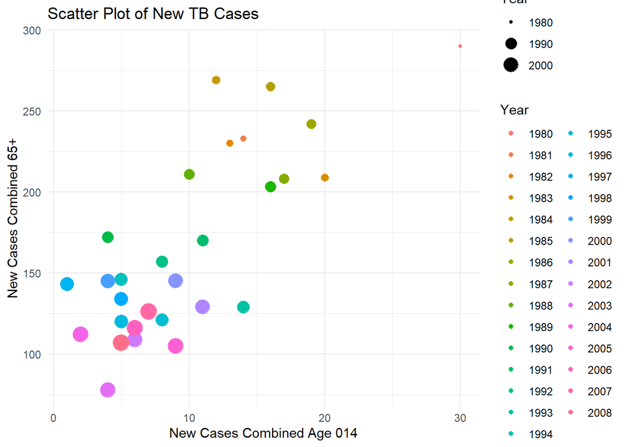

```r
ggplot(data = tbCan, aes(x = new_sp_combined014, y = new_sp_combined65, color = as.factor(year), size = year)) +
  geom_point() +
  labs(x = "New Cases Combined Age 014", y = "New Cases Combined 65+", title = "Scatter Plot of New TB Cases") +
  scale_color_discrete(name = "Year") +
  scale_size_continuous(name = "Year") +
  theme_minimal()
```

14. Interpret this visualization – what insight does it provide?

```r
#This scatterplot gives us a quick and easy way to see which years were particularly bad in terms of new cases for our two ages groups. It also in some sense gives us a eye into the overall trend of positive tests over the years if you look at a sort of line of best fit.
```